# IST Bank & Trust Personal Equity Plan Association Rules

Tim Hulak

```r
# Import libraries for analysis
library(wordcloud2)
library(ggplot2)
library(arules)
library(arulesViz)
library(e1071)
library(dplyr)
```

# Introduction

IST Bank & Trust is reviewing their customer records and wants determine which customer attributes may result in utilizing the new Personal Equity Plan (PEP). A mailing campaign was executed by the Customer Relations & Outreach Department and the results were recorded for this project. In order to identify the correct customers to market this new product to, the technique of Association Rule Mining will be used. This is a data mining method which identifies frequent patterns within a dataset and can help IST Bank & Trust identify attributes in customers that may be good candidates for the new PEP.

The Marketing Department keeps records on customers, including demographic information and number of accounts types. A direct mail piece, advertising the PEP, was sent to existing customers, and a record was kept as to whether that customer responded and bought the product. Based on this store of prior experience, the managers decide to use data mining techniques to build customer profile models.

The goal of this initiative is to perform Association Rule discovery on the provided dataset. Overall, the aim is to identify 20-30 strong rules (rules with high lift and confidence which at the same time have relatively good support) in an effort to identify the best customers to offer a PEP to. Following this analysis, the results will be shared with both the Marketing Department and the Customer Relations & Outreach Department in order to begin developing email and SMS campaigns directed at the identified customers and those who are similar.

# Analysis and Models

## About the Data

The data for this initiative was provided by the Customer Records department at IST Bank & Trust. The dataset contains attributes on each customers demographics and banking information. There are 600 observations of 12 variables:

- **ID**: A unique identification number
- **Age**: The age of customer in years
- **Sex**: Male or Female
- **Region**: What sort of area does the customer live in
- **Income**: Annual income of customer
- **Married**: Is the customer married (YES/NO)
- **Children**: number of children
- **Car**: Does the customer own a car (YES/NO)
- **Savings Account**: Does the customer have a saving account (YES/NO)
- **Current Account**: Does the customer have a current account with IST Bank & Trust (YES/NO)
- **Mortgage**: Does the customer have a mortgage (YES/NO)
- **PEP**: Did the customer buy a PEP after the last mailing (YES/NO)

```r
#Read in Data
bank_data_raw <- read.csv("/Users/timhulak/Desktop/Syracuse/IST-707\ Data\ Analytics/Week_3/bankdata_csv_all.csv")
bank_data <- read.csv("/Users/timhulak/Desktop/Syracuse/IST-707\ Data\ Analytics/Week_3/bankdata_csv_all.csv")
# Preview data
head(bank_data)
```

|  | id | age | sex | region | income | married | children | car | save_act | current_act | mortgage | pep |
| --- | --- | --- | --- | --- | --- | --- | --- | --- | --- | --- | --- | --- |
| 1 | ID12101 | 48 | FEMALE | INNER_CITY | 17546.0 | NO | 1 | NO | NO | NO | NO | YES |
| 2 | ID12102 | 40 | MALE | TOWN | 30085.1 | YES | 3 | YES | NO | YES | YES | NO |
| 3 | ID12103 | 51 | FEMALE | INNER_CITY | 16575.4 | YES | 0 | YES | YES | YES | NO | NO |
| 4 | ID12104 | 23 | FEMALE | TOWN | 20375.4 | YES | 3 | NO | NO | YES | NO | NO |
| 5 | ID12105 | 57 | FEMALE | RURAL | 50576.3 | YES | 0 | NO | YES | NO | NO | NO |
| 6 | ID12106 | 57 | FEMALE | TOWN | 37869.6 | YES | 2 | NO | YES | YES | NO | YES |

```r
# Summarize the Data
summary(bank_data)
```

```
##       id                 age            sex               region
##  Length:600         Min.   :18.00   Length:600         Length:600
##  Class :character   1st Qu.:30.00   Class :character   Class :character
##  Mode  :character   Median :42.00   Mode  :character   Mode  :character
##                     Mean   :42.40
##                     3rd Qu.:55.25
##                     Max.   :67.00
##      income        married             children         car
##  Min.   : 5014   Length:600         Min.   :0.000   Length:600
##  1st Qu.:17264   Class :character   1st Qu.:0.000   Class :character
##  Median :24925   Mode  :character   Median :1.000   Mode  :character
##  Mean   :27524                      Mean   :1.012
##  3rd Qu.:36173                      3rd Qu.:2.000
##  Max.   :63130                      Max.   :3.000
##    save_act         current_act          mortgage             pep
##  Length:600         Length:600         Length:600         Length:600
##  Class :character   Class :character   Class :character   Class :character
##  Mode  :character   Mode  :character   Mode  :character   Mode  :character
##
##
##
```

### Data Preprocessing

```r
# Preview the Structure of the data
str(bank_data)
```

```
## 'data.frame':    600 obs. of  12 variables:
##  $ id         : chr  "ID12101" "ID12102" "ID12103" "ID12104" ...
##  $ age        : int  48 40 51 23 57 57 22 58 37 54 ...
##  $ sex        : chr  "FEMALE" "MALE" "FEMALE" "FEMALE" ...
##  $ region     : chr  "INNER_CITY" "TOWN" "INNER_CITY" "TOWN" ...
##  $ income     : num  17546 30085 16575 20375 50576 ...
##  $ married    : chr  "NO" "YES" "YES" "YES" ...
##  $ children   : int  1 3 0 3 0 2 0 0 2 2 ...
##  $ car        : chr  "NO" "YES" "YES" "NO" ...
##  $ save_act   : chr  "NO" "NO" "YES" "NO" ...
##  $ current_act: chr  "NO" "YES" "YES" "YES" ...
##  $ mortgage   : chr  "NO" "YES" "NO" "NO" ...
##  $ pep        : chr  "YES" "NO" "NO" "NO" ...
```

As seen in the above output, the raw dataset is a mix of character text and integer values. The first step in the preprocessing phase was to convert candidate variables into nominal variables. In other words, columns with values such as “yes” or “no” are converted into factors instead of simply leaving them as text. This will assist in future analysis phases as well as within the algorithm used to determine association rules.

```r
# Convert  columns to factors
bank_data$married <- factor(bank_data$married)
bank_data$children <- factor(bank_data$children)
bank_data$sex <- factor(bank_data$sex)
bank_data$car <- factor(bank_data$car)
bank_data$save_act <- factor(bank_data$save_act)
bank_data$current_act <- factor(bank_data$current_act)
bank_data$mortgage <- factor(bank_data$mortgage)
bank_data$pep <- factor(bank_data$pep)
bank_data$region <- factor(bank_data$region)

# Preview the structure of the new data to ensure that the change was made
str(bank_data)
```

```
## 'data.frame':    600 obs. of  12 variables:
##  $ id         : chr  "ID12101" "ID12102" "ID12103" "ID12104" ...
##  $ age        : int  48 40 51 23 57 57 22 58 37 54 ...
##  $ sex        : Factor w/ 2 levels "FEMALE","MALE": 1 2 1 1 1 1 2 2 1 2 ...
##  $ region     : Factor w/ 4 levels "INNER_CITY","RURAL",..: 1 4 1 4 2 4 2 4 3 4 ...
##  $ income     : num  17546 30085 16575 20375 50576 ...
##  $ married    : Factor w/ 2 levels "NO","YES": 1 2 2 2 2 2 1 2 2 2 ...
##  $ children   : Factor w/ 4 levels "0","1","2","3": 2 4 1 4 1 3 1 1 3 3 ...
##  $ car        : Factor w/ 2 levels "NO","YES": 1 2 2 1 1 1 1 2 2 2 ...
##  $ save_act   : Factor w/ 2 levels "NO","YES": 1 1 2 1 2 2 1 2 1 2 ...
##  $ current_act: Factor w/ 2 levels "NO","YES": 1 2 2 2 1 2 2 2 1 2 ...
##  $ mortgage   : Factor w/ 2 levels "NO","YES": 1 2 1 1 1 1 1 1 1 1 ...
##  $ pep        : Factor w/ 2 levels "NO","YES": 2 1 1 1 1 2 2 1 1 1 ...
```

The next step is to eliminate the ID column. While this column is useful for identifying an individual customer, it is a unique identification number. This means that it will only disrupt the association rule mining process because each value only appears once and will yield no meaningful result.

```r
# Slice the original dataframe to exclude the first row
data <- bank_data[ , -1 ]

# Preview the data
head(data)
```

|  | age | sex | region | income | married | children | car | save_act | current_act | mortgage | pep |
| --- | --- | --- | --- | --- | --- | --- | --- | --- | --- | --- | --- |
| 1 | 48 | FEMALE | INNER_CITY | 17546.0 | NO | 1 | NO | NO | NO | NO | YES |
| 2 | 40 | MALE | TOWN | 30085.1 | YES | 3 | YES | NO | YES | YES | NO |
| 3 | 51 | FEMALE | INNER_CITY | 16575.4 | YES | 0 | YES | YES | YES | NO | NO |
| 4 | 23 | FEMALE | TOWN | 20375.4 | YES | 3 | NO | NO | YES | NO | NO |
| 5 | 57 | FEMALE | RURAL | 50576.3 | YES | 0 | NO | YES | NO | NO | NO |
| 6 | 57 | FEMALE | TOWN | 37869.6 | YES | 2 | NO | YES | YES | NO | YES |

Next, the data is to be discretized, meaning that it will be grouped into like-values and placed into bins in order to categorize the analysis results. Age and income were the numeric variables chosen to be discretized. The ages were bucketed in groups of 10 years and income was bucketed into bins of $10,000<sup>00</sup>.

```r
# Discretize Age
data$age <- cut(data$age, breaks = c(0,10,20,30,40,50,60,Inf), labels = c("CHILD","TEENS","TWENTIES","THIRTIES","FORTIES","FIFTIES","SENIOR"))

# Discretize  Income
data$income <- cut(data$income, breaks = c(0,10000,20000,30000,40000,50000,60000,70000,Inf), labels = c("Less Than 10k","10k-20k","20k-30k","30k-40k","40k-50k","50k-60k","60k-70k","Greater Thank 70k"))

# Convert into factors
bank_data$age <- factor(bank_data$age)
bank_data$income <- factor(bank_data$income)

head(data)
```

|  | age | sex | region | income | married | children | car | save_act | current_act | mortgage | pep |
| --- | --- | --- | --- | --- | --- | --- | --- | --- | --- | --- | --- |
| 1 | FORTIES | FEMALE | INNER_CITY | 10k-20k | NO | 1 | NO | NO | NO | NO | YES |
| 2 | THIRTIES | MALE | TOWN | 30k-40k | YES | 3 | YES | NO | YES | YES | NO |
| 3 | FIFTIES | FEMALE | INNER_CITY | 10k-20k | YES | 0 | YES | YES | YES | NO | NO |
| 4 | TWENTIES | FEMALE | TOWN | 20k-30k | YES | 3 | NO | NO | YES | NO | NO |
| 5 | FIFTIES | FEMALE | RURAL | 50k-60k | YES | 0 | NO | YES | NO | NO | NO |
| 6 | FIFTIES | FEMALE | TOWN | 30k-40k | YES | 2 | NO | YES | YES | NO | YES |

Once the dataset has been prepped, a final check for any missing data was performed. First, the number of complete cases (rows with a valid value in each column) was determined. In order to accomplish this, a count of the rows that are not complete cases is conducted; a count of rows where at least one column was missing a value. In the case of this dataset, all rows are complete cases.

```r
nrow(data[!complete.cases(data),])
```

```
## [1] 0
```

To be thorough, a tally of the NA values in each column individually was conducted. In other words, a scan was done across each column to check for any values that were missing or not applicable. In this dataset, there were no NA values in any of the columns.

```r
for (column in 1:ncol(data)){
  print(paste(colnames(data)[column],": ",length(which(is.na(data[,column])))," NA Values"))
}
```

```
## [1] "age :  0  NA Values"
## [1] "sex :  0  NA Values"
## [1] "region :  0  NA Values"
## [1] "income :  0  NA Values"
## [1] "married :  0  NA Values"
## [1] "children :  0  NA Values"
## [1] "car :  0  NA Values"
## [1] "save_act :  0  NA Values"
## [1] "current_act :  0  NA Values"
## [1] "mortgage :  0  NA Values"
## [1] "pep :  0  NA Values"
```

### Customer Profile

Based on these figures, it can be conclude that the typical customer at IST Bank & Trust is likely middle-aged, on the lower end of the annual income scale, has at least 1 dependent that they will claim on their taxes, lives in the Inner City, and there is a slight chance that they already have a PEP with IST Bank & Trust.

## Exploratory Data Analysis (EDA)

##### Region Word Cloud

```r
region_freq_table <- data.frame(
  "Region" = c("Inner City", "Rural", "Suburban", "Town"),
  "Freq" = c(269, 96, 62, 173)
)

wordcloud2(region_freq_table, size = .5)
```

[interactive chart not shown]

Most of the customers live in the Inner City (44.83%). This is followed by Town at 28.83%, Rural at 16% and Suburban at 10.33%.

#### Sex donut chart

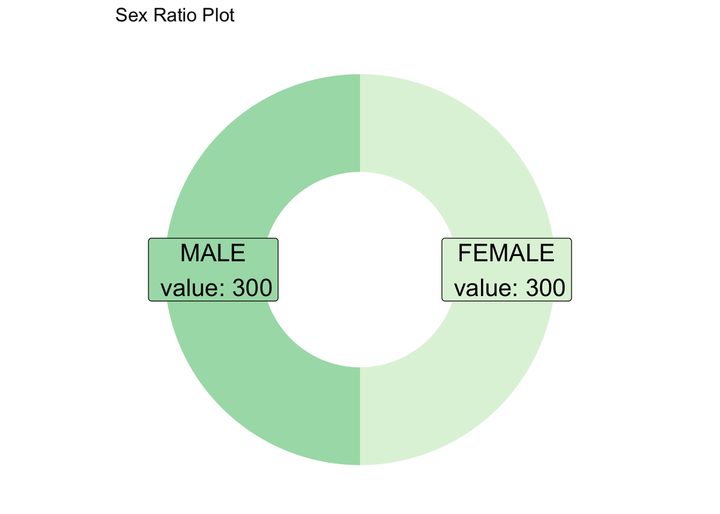

```r
sex_freq <- as.data.frame(table(data$sex))
names(sex_freq)[1] = 'Sex'

# Compute percentages
sex_freq$fraction <- sex_freq$Freq / sum(sex_freq$Freq)

# Compute the cumulative percentages (top of each rectangle)
sex_freq$ymax <- cumsum(sex_freq$fraction)

# Compute the bottom of each rectangle
sex_freq$ymin <- c(0, head(sex_freq$ymax, n=-1))

# Compute label position
sex_freq$labelPosition <- (sex_freq$ymax + sex_freq$ymin) / 2

# Compute a good label
sex_freq$label <- paste0(sex_freq$Sex, "\n value: ", sex_freq$Freq)

ggplot(sex_freq, aes(ymax=ymax, ymin=ymin, xmax=4, xmin=3, fill=Sex)) +
  geom_rect() +
  geom_label( x=3.5, aes(y=labelPosition, label=label), size=6) +
  scale_fill_brewer(palette=4) +
  coord_polar(theta="y") +
  xlim(c(2, 4)) +
  theme_void() +
  theme(legend.position = "none") +
  ggtitle("Sex Ratio Plot")
```

Interestingly, exactly half of the collected data are female clients and the other half are male clients. This may prove problematic because it does not seem as though a fair random sample was taken. Perhaps the Marketing department purposefully send 300 direct mail pieces to male customers and 300 direct mail pieces to female customers, but this has the potential to influence any analysis in an artificial way because it is highly unlikely that he entire population of IST Bank & Trust customers is exactly 50% male and 50% female.

#### Current Account Column Chart

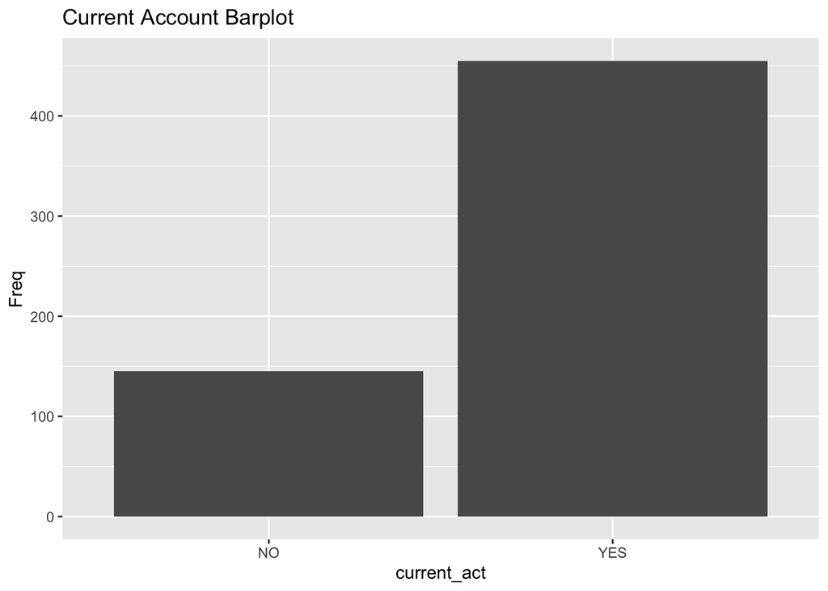

```r
current_act_freq <- as.data.frame(table(data$current_act))
names(current_act_freq)[1] = 'current_act'

ggplot(current_act_freq, aes(x=current_act, y=Freq)) + geom_bar(stat = "identity") + ggtitle("Current Account Barplot")
```

It appears that 75.83% of the 600 customers in the data have an existing account with IST Bank & Trust while 24.17% do not. Upon comparing the two groups (those which have an account and those which do not), they appear to have similar attributes across the variables. The Marketing Department seemed to do a good job when choosing which potential customers, who do not have a current account with IST Bank & Trust, to send the direct mail pieces out to.

```r
no_act <- bank_data_raw[which(bank_data_raw$current_act == "NO"), ]
summary(no_act)
```

```
##       id                 age           sex               region
##  Length:145         Min.   :18.0   Length:145         Length:145
##  Class :character   1st Qu.:32.0   Class :character   Class :character
##  Mode  :character   Median :42.0   Mode  :character   Mode  :character
##                     Mean   :43.3
##                     3rd Qu.:57.0
##                     Max.   :67.0
##      income        married             children     car
##  Min.   : 7606   Length:145         Min.   :0   Length:145
##  1st Qu.:17840   Class :character   1st Qu.:0   Class :character
##  Median :24554   Mode  :character   Median :1   Mode  :character
##  Mean   :26802                      Mean   :1
##  3rd Qu.:33615                      3rd Qu.:2
##  Max.   :57881                      Max.   :3
##    save_act         current_act          mortgage             pep
##  Length:145         Length:145         Length:145         Length:145
##  Class :character   Class :character   Class :character   Class :character
##  Mode  :character   Mode  :character   Mode  :character   Mode  :character
##
##
##
```

```r
act <- bank_data_raw[which(bank_data_raw$current_act == "YES"), ]
summary(act)
```

```
##       id                 age            sex               region
##  Length:455         Min.   :18.00   Length:455         Length:455
##  Class :character   1st Qu.:29.00   Class :character   Class :character
##  Mode  :character   Median :42.00   Mode  :character   Mode  :character
##                     Mean   :42.11
##                     3rd Qu.:54.00
##                     Max.   :67.00
##      income        married             children         car
##  Min.   : 5014   Length:455         Min.   :0.000   Length:455
##  1st Qu.:17144   Class :character   1st Qu.:0.000   Class :character
##  Median :25133   Mode  :character   Median :1.000   Mode  :character
##  Mean   :27754                      Mean   :1.015
##  3rd Qu.:36594                      3rd Qu.:2.000
##  Max.   :63130                      Max.   :3.000
##    save_act         current_act          mortgage             pep
##  Length:455         Length:455         Length:455         Length:455
##  Class :character   Class :character   Class :character   Class :character
##  Mode  :character   Mode  :character   Mode  :character   Mode  :character
##
##
##
```

#### PEP Bar Chart

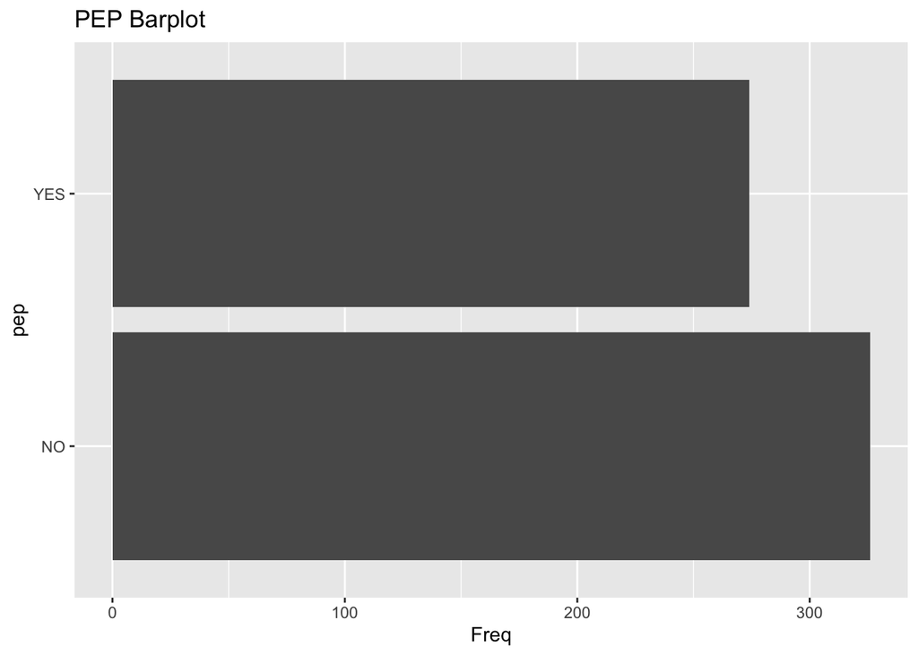

```r
pep_freq <- as.data.frame(table(data$pep))
names(pep_freq)[1] = 'pep'

ggplot(pep_freq, aes(x=pep, y=Freq)) + geom_bar(stat = "identity") + coord_flip() + ggtitle("PEP Barplot")
```

54.33% of the customers from the direct mail campaign *do not* have a PEP with IST Bank & Trust while 45.67% of customers have an existing PEP.

#### Histogram of Income

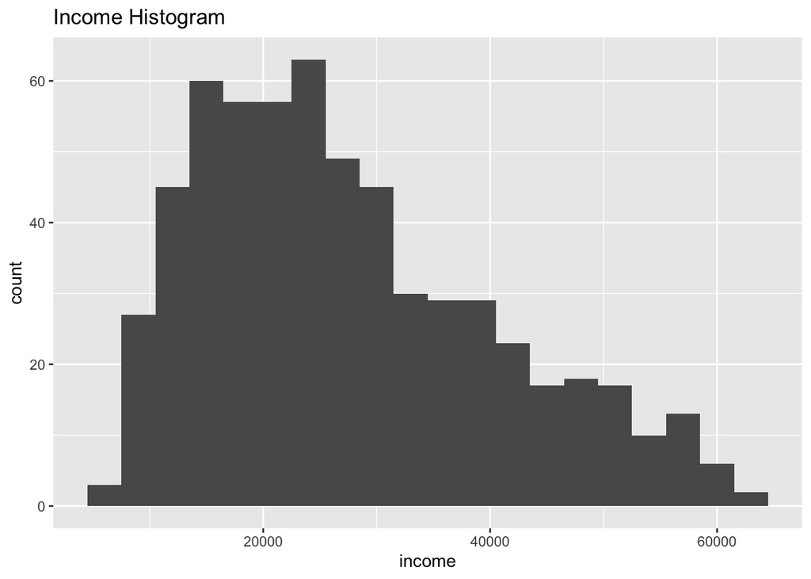

```r
ggplot(bank_data_raw, aes(x=income)) + geom_histogram(binwidth = 3000) + ggtitle("Income Histogram")
```

As seen above, the data for income has a right-skew (Skewness = 0.6612582). This means that the healthy majority of customers are on the lower end of the income range and out outliers are on the higher end of the income range.

#### Boxplot of Age

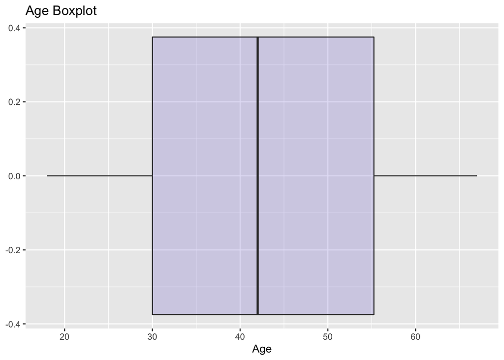

```r
ggplot(bank_data_raw, aes(x=age)) + geom_boxplot(fill="slateblue", alpha=0.2) + xlab("Age") + ggtitle("Age Boxplot")
```

In the above boxplot, the median age of a customer is shown as 42 years old. The bulk of the data appears to be between 30 - 56 years and there also appear to be no statistical outliers.

## Analysis and Model: Aprori Algorithm

In order to use the Apriori algorithm properly, and interpret which column the output is coming from, the YES/NO columns are coerced to generate interpretable rules. In other words, the data is transformed into a transaction format to be input into the Apriori algorithm.

```r
# Finish prep for algorithm. post-EDA
algo_data <- as(data, "transactions")
```

The goal in utilizing this algorithm is to identify 20-30 strong rules. In order to find the correct parameters, different support and confidence thresholds were tested. The confidence was ultimately kept at 0.9 while the support threshold was set at 0.038. This yielded 28 rules, each with a lift above 1 (meaning they are significant and somehow meaningful). The trials for the testing of support and confidence thresholds can be seen below.

- Attempt 1:
  - Support: 0.001
  - Confidence: 0.9
  - **Rules Generated**: 223
- Attempt 2:
  - Support: 0.1
  - Confidence: 0.8
  - **Rules Generated**: 19
- Attempt 3:
  - Support: 0.5
  - Confidence: 0.8
  - **Rules Generated**: 0
- Attempt 4:
  - Support: 0.5
  - Confidence: 0.8
  - **Rules Generated**: 0
- Attempt 5:
  - Support: 0.05
  - Confidence: 0.85
  - **Rules Generated**:32
- Attempt 6:
  - Support: 0.06
  - Confidence: 0.9
  - **Rules Generated**: 7
- Attempt 7:
  - Support: 0.045
  - Confidence: 0.9
  - **Rules Generated**: 21
- Attempt 8:
  - Support: 0.042
  - Confidence: 0.9
  - **Rules Generated**: 24
- Attempt 9:
  - Support: 0.038
  - Confidence: 0.9
  - **Rules Generated**: 28

```r
rules <- apriori(algo_data, parameter = list(supp = 0.038, conf = 0.9, maxlen = 3))
```

```
## Apriori
##
## Parameter specification:
##  confidence minval smax arem  aval originalSupport maxtime support minlen
##         0.9    0.1    1 none FALSE            TRUE       5   0.038      1
##  maxlen target  ext
##       3  rules TRUE
##
## Algorithmic control:
##  filter tree heap memopt load sort verbose
##     0.1 TRUE TRUE  FALSE TRUE    2    TRUE
##
## Absolute minimum support count: 22
##
## set item appearances ...[0 item(s)] done [0.00s].
## set transactions ...[35 item(s), 600 transaction(s)] done [0.00s].
## sorting and recoding items ... [34 item(s)] done [0.00s].
## creating transaction tree ... done [0.00s].
## checking subsets of size 1 2 3
```

```
##  done [0.00s].
## writing ... [28 rule(s)] done [0.00s].
## creating S4 object  ... done [0.00s].
```

```r
rules <- sort(rules, by=c("confidence","support"), decreasing=TRUE)

options(digits=2)
inspect(rules[1:28])
```

```
##      lhs                                   rhs               support confidence
## [1]  {income=40k-50k}                   => {save_act=YES}    0.102   1.00
## [2]  {income=40k-50k,current_act=YES}   => {save_act=YES}    0.082   1.00
## [3]  {income=40k-50k,married=YES}       => {save_act=YES}    0.078   1.00
## [4]  {income=50k-60k}                   => {save_act=YES}    0.070   1.00
## [5]  {income=40k-50k,mortgage=NO}       => {save_act=YES}    0.068   1.00
## [6]  {income=50k-60k,pep=YES}           => {save_act=YES}    0.058   1.00
## [7]  {sex=MALE,income=40k-50k}          => {save_act=YES}    0.058   1.00
## [8]  {income=40k-50k,pep=NO}            => {save_act=YES}    0.058   1.00
## [9]  {income=50k-60k,current_act=YES}   => {save_act=YES}    0.055   1.00
## [10] {age=FORTIES,children=1}           => {pep=YES}         0.053   1.00
## [11] {income=40k-50k,car=YES}           => {save_act=YES}    0.052   1.00
## [12] {age=SENIOR,income=50k-60k}        => {save_act=YES}    0.050   1.00
## [13] {income=40k-50k,children=0}        => {save_act=YES}    0.050   1.00
## [14] {income=40k-50k,car=NO}            => {save_act=YES}    0.050   1.00
```

[output cut: 43 more lines]

Since IST Bank & Trust is attempting to identify candidates to market the PEP to, the rules for customers who have PEP was used (pep=pep=YES) for the right hand side of the algorithm.

```r
rules <- apriori(data = algo_data, parameter = list(supp=0.038,conf = 0.9, minlen=3),
               appearance = list(default = "lhs", rhs = "pep=YES"),
               control = list(verbose = F))

summary(rules)
```

```
## set of 26 rules
##
## rule length distribution (lhs + rhs):sizes
##  3  4  5  6
##  3  9 10  4
##
##    Min. 1st Qu.  Median    Mean 3rd Qu.    Max.
##     3.0     4.0     5.0     4.6     5.0     6.0
##
## summary of quality measures:
##     support        confidence      coverage          lift          count
##  Min.   :0.038   Min.   :0.90   Min.   :0.040   Min.   :1.97   Min.   :23
##  1st Qu.:0.042   1st Qu.:0.92   1st Qu.:0.043   1st Qu.:2.01   1st Qu.:25
##  Median :0.044   Median :0.93   Median :0.047   Median :2.03   Median :26
##  Mean   :0.048   Mean   :0.94   Mean   :0.051   Mean   :2.06   Mean   :29
##  3rd Qu.:0.051   3rd Qu.:0.96   3rd Qu.:0.053   3rd Qu.:2.10   3rd Qu.:30
##  Max.   :0.075   Max.   :1.00   Max.   :0.080   Max.   :2.19   Max.   :45
##
## mining info:
##       data ntransactions support confidence
##  algo_data           600   0.038        0.9
```

# Results

```r
rules <- sort(rules, decreasing= T, by= c("confidence","support"))

options(digits=2)
inspect(rules[1:26])
```

```
##      lhs                    rhs       support confidence coverage lift count
## [1]  {age=FORTIES,
##       children=1}        => {pep=YES}   0.053       1.00    0.053  2.2    32
## [2]  {income=20k-30k,
##       married=YES,
##       children=1}        => {pep=YES}   0.047       1.00    0.047  2.2    28
## [3]  {age=FORTIES,
##       children=1,
##       save_act=YES}      => {pep=YES}   0.043       1.00    0.043  2.2    26
## [4]  {age=FORTIES,
##       children=1,
##       current_act=YES}   => {pep=YES}   0.042       1.00    0.042  2.2    25
## [5]  {married=NO,
##       children=0,
##       save_act=YES,
##       mortgage=NO}       => {pep=YES}   0.052       0.97    0.053  2.1    31
## [6]  {income=30k-40k,
##       children=1}        => {pep=YES}   0.043       0.96    0.045  2.1    26
## [7]  {married=NO,
##       children=0,
##       save_act=YES,
##       current_act=YES,
##       mortgage=NO}       => {pep=YES}   0.042       0.96    0.043  2.1    25
## [8]  {income=20k-30k,
##       children=1,
##       save_act=YES}      => {pep=YES}   0.038       0.96    0.040  2.1    23
## [9]  {income=20k-30k,
##       children=1}        => {pep=YES}   0.062       0.95    0.065  2.1    37
## [10] {married=NO,
##       children=0,
##       current_act=YES,
##       mortgage=NO}       => {pep=YES}   0.058       0.95    0.062  2.1    35
## [11] {married=NO,
##       children=0,
##       mortgage=NO}       => {pep=YES}   0.075       0.94    0.080  2.1    45
## [12] {income=20k-30k,
##       children=1,
##       current_act=YES}   => {pep=YES}   0.047       0.93    0.050  2.0    28
## [13] {region=TOWN,
##       married=YES,
```

[output cut: 39 more lines]

```
##       save_act=YES,
##       current_act=YES,
##       mortgage=NO}       => {pep=YES}   0.048       0.91    0.053  2.0    29
## [24] {children=1,
##       car=YES,
##       save_act=YES,
##       mortgage=NO}       => {pep=YES}   0.047       0.90    0.052  2.0    28
## [25] {region=INNER_CITY,
##       children=1,
##       save_act=YES,
##       current_act=YES}   => {pep=YES}   0.045       0.90    0.050  2.0    27
## [26] {married=YES,
##       children=1,
##       car=NO,
##       current_act=YES}   => {pep=YES}   0.045       0.90    0.050  2.0    27
```

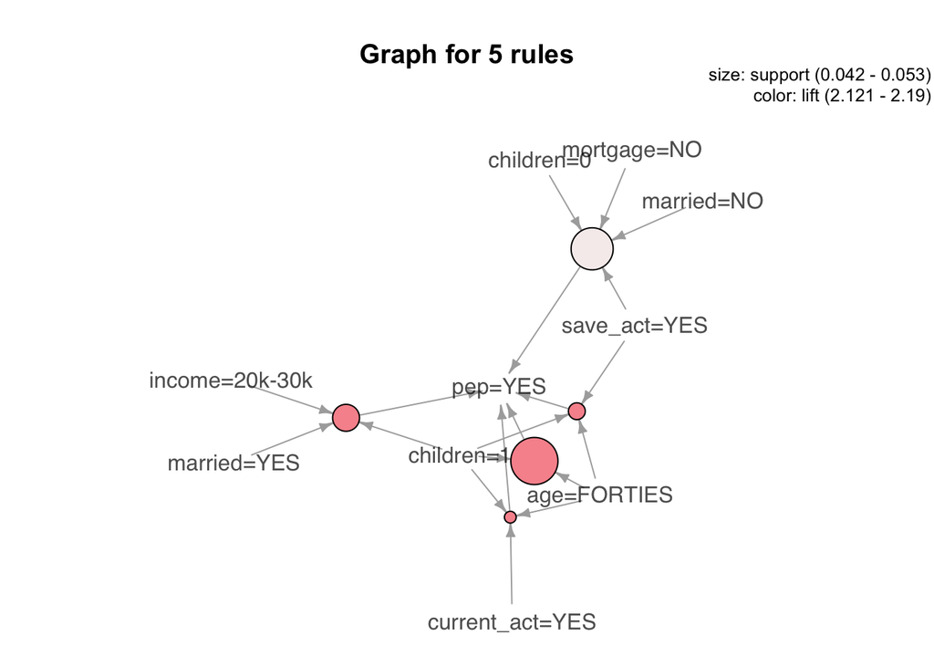

```r
top_5 <- head(sort(rules, by = "lift", 10),5)
plot(top_5, method="graph")
```

Some preliminary rules that were interesting can be seen below. While not the “official” top 5 rules (according to their support, confidence, and lift), each of these 4 rules included an itemset of 5 items on the left hand side which were associated with having a PEP. These rules were included for consideration because they cover the most variables on the left hand side. In other words, they may be a good starting point to test against the aforementioned customer profile as a preliminary threshold for candidacy prior to applying the more specific rules.

- {married=NO,children=0,save_act=YES,current_act=YES,mortgage=NO} => {pep=YES}
  - Support: 0.042
  - Confidence: 0.96
  - Lift: 2.1
- {children=1,car=YES,save_act=YES,current_act=YES,mortgage=NO} => {pep=YES}
  - Support: 0.038
  - Confidence: 0.92
  - Lift: 2.0
- {sex=MALE,married=YES,children=1,save_act=YES,current_act=YES} => {pep=YES}
  - Support: 0.038
  - Confidence: 0.92
  - Lift: 2.0
- {married=YES,children=1,save_act=YES,current_act=YES,mortgage=NO} => {pep=YES}
  - Support: 0.048
  - Confidence: 0.91
  - Lift: 2.0

- **Rule 1:** {age=FORTIES,children=1} => {pep=YES}
  - Support: 0.053
  - Confidence: 1.00
  - Lift: 2.2
  - Count: 32
- **Rule 2:** {income=20k-30k,married=YES,children=1} => {pep=YES}
  - Support: 0.047
  - Confidence: 1.00
  - Lift: 2.2
  - Count: 28
- **Rule 3:** {age=FORTIES,children=1,save_act=YES} => {pep=YES}
  - Support: 0.043
  - Confidence: 1.00
  - Lift: 2.2
  - Count: 26
- **Rule 4:** {age=FORTIES,children=1,current_act=YES} => {pep=YES}
  - Support: 0.042
  - Confidence: 1.00
  - Lift: 2.2
  - Count: 25
- **Rule 5:** {married=NO,children=0,save_act=YES,mortgage=NO} => {pep=YES}
  - Support: 0.052
  - Confidence: 0.97
  - Lift: 2.1
  - Count: 31

# Conclusions

IST Bank & Trust has tasked the data science team with identifying which customers would make the best candidates for the PEP initiative. The Apriori algorithm was used to identify association rules for the best candidates, based on a sample data of 600 individuals from a direct mail campaign. Exploratory data analysis revealed that the typical customer at IST Bank & Trust is likely middle-aged, on the lower end of the annual income scale, has at least 1 dependent that they will claim on their taxes, lives in the Inner City, and there is a slight chance that they already have a PEP with IST Bank & Trust.